# **Reproducible Research - Course Project 1**

##### **Loading and preprocessing the data**

1. Load the data (i.e. read.csv())

```r
library(lattice)
df <- read.csv("activity.csv", na.strings = "NA", stringsAsFactors = FALSE)
```

2. Process/transform the data (if necessary) into a format suitable for your analysis

```r
df$date <- as.POSIXct(df$date, format="%Y-%m-%d")
```

##### **What is mean total number of steps taken per day?**

1. Calculate the total number of steps taken per day

```r
sum_steps <- aggregate(df$steps, by=list(df$date), FUN = sum, na.rm=TRUE)
names(sum_steps) <- c("date","steps")
```

2. Make a histogram of the total number of steps taken each day

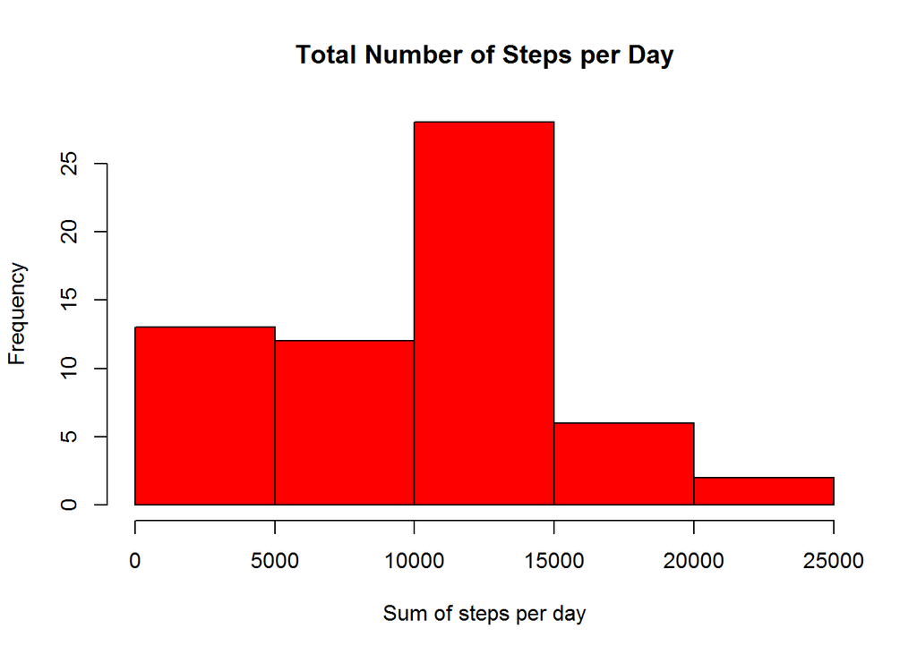

```r
hist(sum_steps$steps, xlab = "Sum of steps per day", main = "Total Number of Steps per Day", col="red")
```

3. Calculate and report the mean and median of the total number of steps taken per day

```r
step_mean <- mean(sum_steps$steps)
step_median <- median(sum_steps$steps)
```

The mean is 9354.2295082 and the median is 10395

##### **What is the average daily activity pattern?**

1. Make a time series plot (i.e. type = “l”) of the 5-minute interval (x-axis) and the average number of steps taken, averaged across all days (y-axis)

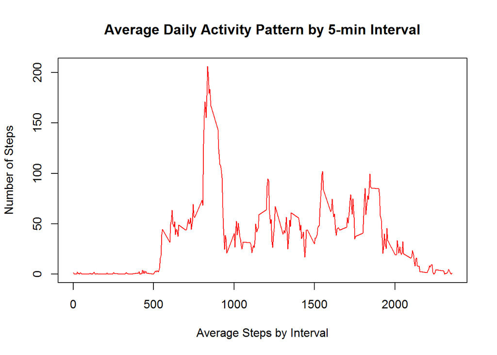

```r
mean_steps <- aggregate(df$steps, by=list(df$interval), FUN = mean, na.rm=TRUE)
names(mean_steps) <- c("interval","steps")

plot(mean_steps$interval,mean_steps$steps,type = "l",xlab = "Average Steps by Interval",ylab = "Number of Steps",
     main = "Average Daily Activity Pattern by 5-min Interval", col="red")
```

2. Which 5-minute interval, on average across all the days in the dataset, contains the maximum number of steps?

```r
max_steps <- which(mean_steps$steps == max(mean_steps$steps))
max_interval <- mean_steps[max_steps,1]
```

The 835 interval contains the maximum number of steps

##### **Imputing missing values**

1. Calculate and report the total number of missing values in the dataset (i.e. the total number of rows with NAs)

```r
cnt_na <- sum(is.na(df$steps))
```

The total number of missing values in the dataset is 2304

2. Devise a strategy for filling in all of the missing values in the dataset. The strategy does not need to be sophisticated. For example, you could use the mean/median for that day, or the mean for that 5-minute interval, etc.

```r
na_steps <- which(is.na(df$steps))
mean_steps2 <- rep(mean(df$steps, na.rm=TRUE), times=length(na_steps))
```

3. Create a new dataset that is equal to the original dataset but with the missing data filled in.

```r
df2 <- df
df2[na_steps, "steps"] <- mean_steps2
```

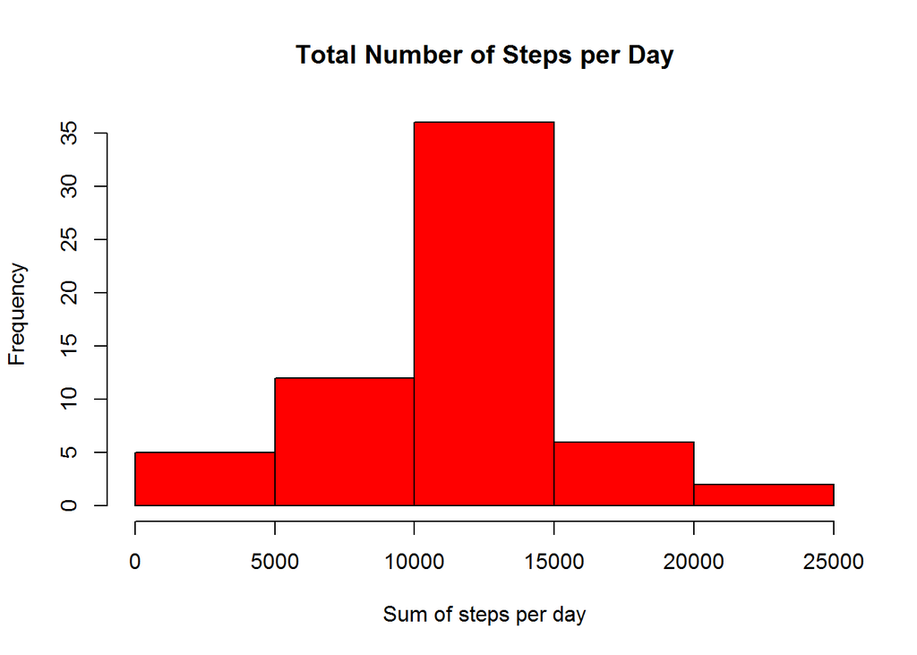

```r
sum_steps2 <- aggregate(df2$steps, by=list(df2$date), FUN = sum, na.rm=TRUE)
names(sum_steps2) <- c("date","steps")
hist(sum_steps2$steps, xlab = "Sum of steps per day", main = "Total Number of Steps per Day", col="red")
```

```r
step2_mean <- mean(sum_steps2$steps)
step2_median <- median(sum_steps2$steps)
```

##### **Are there differences in activity patterns between weekdays and weekends?**

1. Create a new factor variable in the dataset with two levels - “weekday” and “weekend” indicating whether a given date is a weekday or weekend day.

```r
df2$weekday <- weekdays(df2$date)
df2$daytype <- ifelse(df2$weekday == "Sunday" | df2$weekday == "Saturday",
                     "Weekend", "Weekday")
```

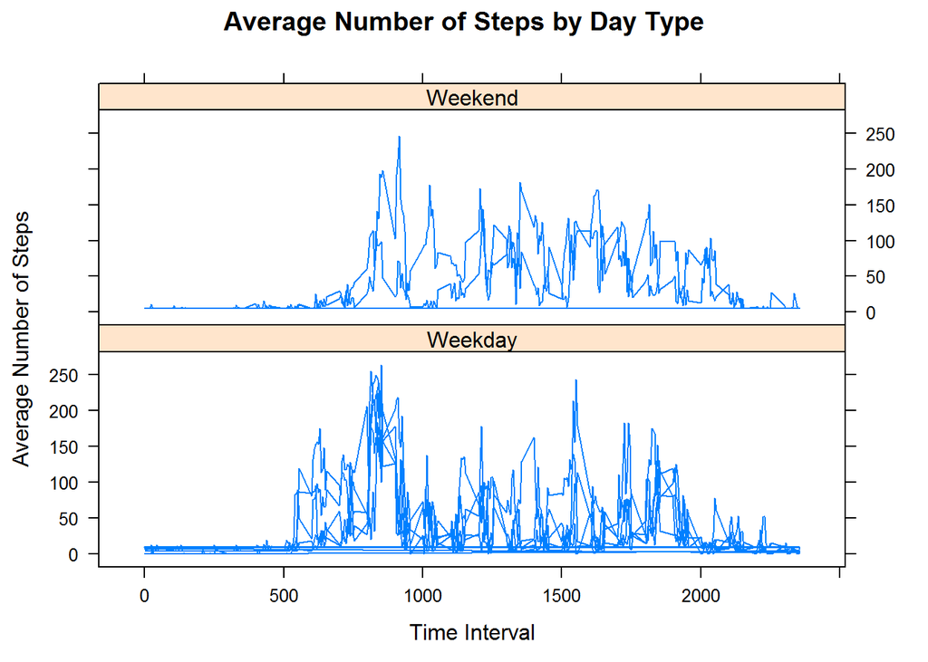

```r
mean_steps3 <- aggregate(df2$steps, by=list(df2$interval, df2$weekday, df2$daytype), FUN = mean, na.rm=TRUE)
names(mean_steps3) <- c("interval","weekday","daytype","steps")
xyplot(steps ~ interval | daytype, mean_steps3, type = "l", xlab = "Time Interval",ylab = "Average Number of Steps",
       main= "Average Number of Steps by Day Type",layout= c(1,2))
```